# Variance Project: Qualitative Analysis

## Introduction

Exploring use qualitative ENA with Variance talents.

## Methods

# Descriptive Statistics

## Videos included in the analysis

Table below includes definitions for each of the genres

|  | Field Name | Definition |
| --- | --- | --- |
| 1 | collaborative_energy | Content emphasizing collaboration between multiple creators or guests. |
| 2 | community_milestones | Content tied to audience/community milestones, anniversaries, debuts, or special events. |
| 3 | interactive_entertainment | Content framed around active play, challenge, or audience-participatory entertainment. |
| 4 | meme_viral | Content framed around memes, trends, shitpost energy, or intentionally viral phrasing. |
| 5 | monetization | Content explicitly tied to sponsorship, paid events, merch, membership, or commercial calls-to-action. |
| 6 | narrative_serialization | Content explicitly positioned as part of an ongoing sequence, arc, season, or numbered series. |
| 7 | performance_artistry | Content centered on musical or performative expression as the primary focus (singing, karaoke, covers, concerts, instrument performance, music videos). |
| 8 | personality_conversation | Content centered on direct speaking, Q&amp;A, life updates, reactions, or open conversation. |

The table shows the distribution of different types of content from the sample.

|  | Talent Name | Content Category | N Videos | Pct Videos |
| --- | --- | --- | --- | --- |
| 1 | Ava | personality_conversation | 6 | 0.6666666666666666 |
| 2 | Ava | interactive_entertainment | 2 | 0.2222222222222222 |
| 3 | Ava | monetization | 1 | 0.1111111111111111 |
| 4 | Katya | personality_conversation | 9 | 0.6428571428571429 |
| 5 | Katya | interactive_entertainment | 2 | 0.1428571428571428 |
| 6 | Katya | narrative_serialization | 2 | 0.1428571428571428 |
| 7 | Katya | community_milestones | 1 | 0.07142857142857142 |
| 8 | Leia | personality_conversation | 6 | 0.6 |
| 9 | Leia | interactive_entertainment | 2 | 0.2 |
| 10 | Leia | collaborative_energy | 1 | 0.1 |

[output cut: 1 more lines]

## Lines of text associated with each genre

|  | Talent Name | Stream Title | Total Lines Of Text | N Donations | Total Donations | Min Donation | Max Donation | Avg Donation | Median Donation |
| --- | --- | --- | --- | --- | --- | --- | --- | --- | --- |
| 1 | Ava | DRESS UP DRAGONOID + ANNOUNCEMENT | 5510 | 47 | 264.82 | 1.9 | 20 | 5.634468085106383 | 5 |
| 2 | Ava | you want milk in your latte? 🍼 | 6690 | 30 | 194.68 | 1 | 50 | 6.489333333333334 | 5 |
| 3 | Ava | MONETIZATION BLOOD PARTY | 4253 | 30 | 179.9678 | 1.99 | 20.7126 | 5.998926666666667 | 5 |
| 4 | Ava | i can suck responsibly 💋 【LOLLIPOP CHAINSAW】 | 3277 | 26 | 171.59 | 1.9 | 50 | 6.599615384615385 | 5 |
| 5 | Ava | DINNER AND ALCOHOL ✨ 【HANDCAM】 | 4724 | 27 | 171.44 | 1 | 50 | 6.34962962962963 | 5 |
| 6 | Ava | BATHING IN BLOOD 💞 | 4068 | 25 | 160.0526 | 1 | 54 | 6.402104 | 5 |
| 7 | Ava | LAST TIME YOU'LL SEE THE OUTFIT, GOT IT?! 💢 | 5468 | 23 | 144.84 | 1 | 20 | 6.297391304347826 | 5 |
| 8 | Ava | hold my sweater Slay the Spire 2 is out | 2990 | 26 | 143.3 | 1.9 | 20 | 5.511538461538461 | 5 |
| 9 | Katya | addressing the elephant | 2709 | 25 | 127.552 | 0.11 | 14.8 | 5.10208 | 5 |
| 10 | Ava | LIGHT ME UP, BABY【HANDCAM】 | 3792 | 18 | 100.22 | 2 | 20 | 5.567777777777778 | 4.99 |

[output cut: 20 more lines]

## Amount of Money by each stream and streamer

Note that this is a check to deteremine that there is an average range. The assumption was that I picked streams that at least had money in them, so none of these streams had $0.

[interactive chart not shown]

# Qualitative Analysis: Epistemic Network Analysis

## Qualitative Codebook

These codes are a combination of chat specific codes focusing on generalized chat behvaior, while focusing on generalized streamer responses. These are intended to be broad behvaiors to identify if there’s a simpler solution to understanding the relationship between streamer and chat.

|  | Code ID | Code Label | Definition |
| --- | --- | --- | --- |
| 1 | A1a | Ceremonial reception framing | Assign this streamer code only to streamer transcript rows. Code the row when the streamer acknowledges supporter activity as initiation, blessing, staged welcome, ceremonial reception, or induction r… |
| 2 | A1b | Reciprocal gratitude/check-in loop | Assign this streamer code only to streamer transcript rows. Code the row when the streamer thanks viewers for waiting, being present, checking in, giving, gifting, joining, or otherwise supporting, an… |
| 3 | B1 | Audience pacing and room control | Assign this streamer code only to streamer transcript rows. Code the row when the streamer visibly steers chat attention, transitions, interaction timing, pinning, moderation, explanation, or refocusi… |
| 4 | C1 | Reassurance and tension repair | Assign this streamer code only to streamer transcript rows. Code the row when the streamer normalizes setbacks, soothes tension, repairs embarrassment or frustration, or reassures chat, themself, or a… |
| 5 | CP03 | Synchronized Reaction Bursts | Assign this chat code only to chat message rows. Code the row when chat compresses collective emotion into dense short-form reactions that cluster around the same stream moment, such as synchronized h… |
| 6 | CP06 | Collective In-Group Framing | Assign this chat code only to chat message rows. Code the row when chat frames itself, the streamer, or the room as a shared in-group through collective labels, belonging language, shared fate, or com… |
| 7 | CP09 | Shared Callback And Local Lore Invocation | Assign this chat code only to chat message rows. Code the row when chat invokes recurring local callbacks, memes, named bits, or lore phrases that depend on shared memory within the streamer community… |
| 8 | CP11 | Chant-Led Room Rallying | Assign this chat code only to chat message rows. Code the row when chat uses repeated slogans, chants, or formulaic calls to rally the room, synchronize attention, mark transitions, or build current-m… |
| 9 | CP13 | Affectionate Appraisal And Thanks | Assign this chat code only to chat message rows. Code the row when chat offers affection, gratitude, compliments, personal affirmation, or appreciative appraisal directed toward the streamer or commun… |
| 10 | E1a | Mock-ominous welcome play | Assign this streamer code only to streamer transcript rows. Code the row when the streamer uses teasing, welcome, threat-tinged, dark, mock-ominous, or grandiose language as rapport-building performan… |

[output cut: 1 more lines]

## Code Selection

The table below identifies the qualitative codes that will be carried forward into the ENA model. First, each transcript row is scanned with a rolling window of the current row plus the previous four rows from the same stream. Codes that appear within the same window are counted as co-occurring pairs. `pair_participation_count` is the total number of windowed co-occurrences involving that code, while `distinct_pair_count` is the number of different code relationships that code participates in. Codes are ranked by these counts, then parent/child duplicates are removed so the selected set favors the more specific secondary code when both a primary and secondary code appear.

|  | Code | Code Label | Pair Participation Count | Distinct Pair Count |
| --- | --- | --- | --- | --- |
| 1 | B1 | Audience pacing and room control | 20128 | 10 |
| 2 | CP13 | Affectionate Appraisal And Thanks | 17328 | 10 |
| 3 | CP03 | Synchronized Reaction Bursts | 16045 | 10 |
| 4 | C1 | Reassurance and tension repair | 6698 | 10 |
| 5 | CP11 | Chant-Led Room Rallying | 6173 | 10 |
| 6 | A1b | Reciprocal gratitude/check-in loop | 5843 | 10 |
| 7 | CP06 | Collective In-Group Framing | 4329 | 10 |
| 8 | E1a | Mock-ominous welcome play | 4271 | 10 |

Next rather than looking at individual codes, I also examined code pairs to determine which sets of code pairs were the most common. This is because ENA is ultimately looking at code co-occurence, so understanding which codes are commonly co-occuring can be helpful for understanding the data and validating the code selection. The table below shows the most common code pairs, which again validates the code selection as these pairs are made up of the codes that were selected for the model.

|  | Code Pair | Code Pair Label | Window Pair Count | Pct Pair Windows | Code 1 | Code 1 Label | Code 2 | Code 2 Label |
| --- | --- | --- | --- | --- | --- | --- | --- | --- |
| 1 | B1 + CP13 | Audience pacing and room control + Affectionate Appraisal And Thanks | 5715 | 0.1313944131509369 | B1 | Audience pacing and room control | CP13 | Affectionate Appraisal And Thanks |
| 2 | B1 + CP03 | Audience pacing and room control + Synchronized Reaction Bursts | 5547 | 0.1275319002184159 | B1 | Audience pacing and room control | CP03 | Synchronized Reaction Bursts |
| 3 | CP03 + CP13 | Synchronized Reaction Bursts + Affectionate Appraisal And Thanks | 3908 | 0.0898494079779285 | CP03 | Synchronized Reaction Bursts | CP13 | Affectionate Appraisal And Thanks |
| 4 | B1 + C1 | Audience pacing and room control + Reassurance and tension repair | 2176 | 0.05002873893550983 | B1 | Audience pacing and room control | C1 | Reassurance and tension repair |
| 5 | B1 + CP11 | Audience pacing and room control + Chant-Led Room Rallying | 1825 | 0.04195884584434992 | B1 | Audience pacing and room control | CP11 | Chant-Led Room Rallying |
| 6 | C1 + CP13 | Reassurance and tension repair + Affectionate Appraisal And Thanks | 1754 | 0.04032647430739165 | C1 | Reassurance and tension repair | CP13 | Affectionate Appraisal And Thanks |
| 7 | A1b + CP13 | Reciprocal gratitude/check-in loop + Affectionate Appraisal And Thanks | 1716 | 0.03945281066789286 | A1b | Reciprocal gratitude/check-in loop | CP13 | Affectionate Appraisal And Thanks |
| 8 | A1b + B1 | Reciprocal gratitude/check-in loop + Audience pacing and room control | 1523 | 0.03501551902517531 | A1b | Reciprocal gratitude/check-in loop | B1 | Audience pacing and room control |
| 9 | CP03 + CP11 | Synchronized Reaction Bursts + Chant-Led Room Rallying | 1490 | 0.03425681112771583 | CP03 | Synchronized Reaction Bursts | CP11 | Chant-Led Room Rallying |
| 10 | C1 + CP03 | Reassurance and tension repair + Synchronized Reaction Bursts | 1271 | 0.02922174962639384 | C1 | Reassurance and tension repair | CP03 | Synchronized Reaction Bursts |

[output cut: 45 more lines]

## Ava

[interactive chart not shown]

## Katya

[interactive chart not shown]

## Leia

[interactive chart not shown]

# Linear Regression Analysis

## Predictive Modeling Goal

The goal of this section is predictive rather than causal. The question is whether stream activity, content classifications, and ENA lineweight features help predict stream-level donations. Because there are only about 30 streams, the workflow keeps the unregularized linear models small and uses penalized regression for the ENA-heavy models.

Donation-count and donation-size summaries are excluded from the main predictors because they mechanically summarize the outcome. The main outcome is `log1p(total_donations)`, which reduces the influence of highly skewed stream revenue. The expanded baseline includes stream analytics such as views, watch time, retention, subscriber change, duration, and publish timing.

## Modeling Data Preparation

The modeling dataset keeps one row per stream. Sparse topics are collapsed into an `Other` category so that the small sample does not create unstable one-observation dummy variables. Logical classification columns are converted to numeric 0/1 predictors. ENA lineweights are already numeric and are standardized internally by `glmnet`.

## Model Comparison

The models are evaluated with leave-one-out cross-validation. This is more defensible for a small sample than in-sample fit statistics, though the results should still be interpreted as exploratory because each fold is trained on a very small dataset.

|  | Model ID | Model Family | N Streams | Rmse Log | Mae Log | R Squared Log | Rmse Dollars | Mae Dollars |
| --- | --- | --- | --- | --- | --- | --- | --- | --- |
| 1 | C. Analytics baseline + ENA ridge | glmnet_alpha_0 | 30 | 0.6566272204609476 | 0.5733846002036136 | 0.03741938471855766 | 62.1562882423161 | 48.31218747269272 |
| 2 | D. Full ridge | glmnet_alpha_0 | 30 | 0.6710742122549802 | 0.5843934302950687 | -0.005403625906379439 | 63.2012157048159 | 49.25433680216008 |
| 3 | D. Full lasso | glmnet_alpha_1 | 30 | 0.6885741635028486 | 0.595244483592865 | -0.05852420411995052 | 66.54018535028979 | 51.01134876896413 |
| 4 | C. Analytics baseline + ENA elastic net | glmnet_alpha_0.5 | 30 | 0.7113926887152227 | 0.6199356481823713 | -0.1298431099161526 | 68.32009101567252 | 53.7717365435529 |
| 5 | C. Analytics baseline + ENA lasso | glmnet_alpha_1 | 30 | 0.7245953407717447 | 0.6097886354012094 | -0.1721695111223183 | 72.50413430619983 | 54.08276222564361 |
| 6 | A0. Original baseline | linear_lm | 30 | 0.7559644537184732 | 0.6376018524800922 | -0.275857281591058 | 65.22159099509913 | 51.40031961526986 |
| 7 | A. Analytics baseline | linear_lm | 30 | 0.7882274428770166 | 0.6454111708418035 | -0.3870829995829461 | 81.73015258126877 | 59.41406871711425 |
| 8 | D. Full elastic net | glmnet_alpha_0.5 | 30 | 0.8433737700798808 | 0.7111223148514269 | -0.5879598819471938 | 107.1211710628468 | 69.49015768156806 |
| 9 | B. Analytics baseline + content classifications | linear_lm | 30 | 1.058395063589805 | 0.8022681618620927 | -1.500892118291723 | 117.5941822927415 | 76.52894560355074 |

## Strongest Predictors

The ENA-heavy models use penalization because there are many lineweight predictors relative to the number of streams. Elastic net is the preferred ENA specification because ENA lineweights are likely correlated, but the table below uses whichever penalized model has the best leave-one-out RMSE on the log donation outcome.

|  | Predictor | Coefficient | Abs Coefficient |
| --- | --- | --- | --- |
| 1 | lw_code_C1_code_CP06 | -1.420791024539812 | 1.420791024539812 |
| 2 | lw_code_C1_code_CP11 | 0.9275744733707054 | 0.9275744733707054 |
| 3 | lw_code_CP13_code_CP11 | 0.8850579797179537 | 0.8850579797179537 |
| 4 | lw_code_A1b_code_E1a | 0.8802504856900407 | 0.8802504856900407 |
| 5 | lw_code_CP11_code_A1b | 0.6510593146720773 | 0.6510593146720773 |
| 6 | lw_code_CP11_code_CP06 | 0.6034492002115746 | 0.6034492002115746 |
| 7 | lw_code_C1_code_A1b | -0.4263953888040877 | 0.4263953888040877 |
| 8 | lw_code_CP11_code_E1a | 0.3273218336379212 | 0.3273218336379212 |
| 9 | lw_code_B1_code_E1a | -0.3257646414178746 | 0.3257646414178746 |
| 10 | lw_code_CP13_code_CP06 | 0.3235177264508859 | 0.3235177264508859 |

[output cut: 30 more lines]

## Diagnostic Plots

These plots show predictive behavior for the best-performing model. They are checks on prediction quality, not evidence of causal effects. The interactive versions are helpful for identifying which specific streams are driving errors or unusual coefficient patterns.

### Observed vs Predicted Donations

This plot checks whether the best model is generally close to the donation totals it is trying to predict. Points near the dashed line are better predictions. Points far above the line are over-predictions, and points far below the line are under-predictions.

[interactive chart not shown]

### Residuals vs Fitted Values

This plot checks whether prediction errors are randomly scattered across the range of fitted values. A strong curve, funnel shape, or cluster of large residuals would suggest the model is missing structure or struggling with a subset of streams.

[interactive chart not shown]

### Retained Predictors

This plot shows the non-zero predictors retained by the best penalized model. Larger absolute coefficients indicate stronger predictive weight in the penalized model, but with this sample size they should be treated as hypothesis-generating rather than stable causal estimates.

[interactive chart not shown]

## Validity Checks

These checks build on the selected best model from the model comparison table. They ask whether the model appears meaningfully predictive, whether the retained predictors are stable under resampling, and whether any follow-up interpretation is warranted. The framing remains exploratory and predictive, not causal.

### Best Model Summary

The best model is selected using the same criterion as the main comparison: lowest leave-one-out cross-validated RMSE on the log-transformed donation outcome. This keeps the validity checks aligned with the model selection workflow rather than assuming in advance that lasso, ridge, elastic net, or a linear model should win.

|  | Selected Model ID | Model Family | Predictor Set | Number Of Streams | Rmse Log | Mae Log | R Squared Log | Rmse Dollars | Mae Dollars | N Retained Predictors |
| --- | --- | --- | --- | --- | --- | --- | --- | --- | --- | --- |
| 1 | C. Analytics baseline + ENA ridge | glmnet_alpha_0 | log_lines_of_text, topic_lumped, log_analytics_views, log_analytics_estimated_minutes_watched, log_analytics_average_view_duration, analytics_average_view_percentage, analytics_subscribers_gained, ana… | 30 | 0.6566272204609476 | 0.5733846002036136 | 0.03741938471855766 | 62.1562882423161 | 48.31218747269272 | 40 |

The selected model is the one with the lowest leave-one-out RMSE on `log1p(total_donations)`. This means it performed best in the current predictive comparison, but it should not be read as a causal explanation of why streams received donations.

### Predictive Validity Checks

These diagnostics focus on the selected model’s predictions. The goal is to see whether errors are small enough to be useful and whether certain streams, topics, or talents are consistently missed.

|  | Talent Name | Video ID | Stream Label | Topic | Topic Lumped | Observed Total Donations | Predicted Total Donations | Prediction Error | Absolute Prediction Error | Percent Error |
| --- | --- | --- | --- | --- | --- | --- | --- | --- | --- | --- |
| 1 | Ava | vWDHa2POUzk | DRESS UP DRAGONOID + ANNOUNCEMENT | free_chat_zatsu | free_chat_zatsu | 264.82 | 80.7209336778466 | 184.0990663221534 | 184.0990663221534 | 0.6951856593994162 |
| 2 | Ava | -6_UhwQ_mgQ | MONETIZATION BLOOD PARTY | other | Other | 179.9678 | 69.34455552408755 | 110.6232444759125 | 110.6232444759125 | 0.6146835404773101 |
| 3 | Ava | JjcZ9MyZhxE | you want milk in your latte? 🍼 | free_chat_zatsu | free_chat_zatsu | 194.68 | 85.71754969940625 | 108.9624503005938 | 108.9624503005938 | 0.559700278922302 |
| 4 | Ava | NUNZRMuUDRs | i can suck responsibly 💋 【LOLLIPOP CHAINSAW】 | gaming | gaming | 171.59 | 70.81241110597865 | 100.7775888940213 | 100.7775888940213 | 0.5873162124484023 |
| 5 | Ava | v4YknSyk6P0 | DINNER AND ALCOHOL ✨ 【HANDCAM】 | art_handcam_creation | art_handcam_creation | 171.44 | 75.50262119075788 | 95.93737880924212 | 95.93737880924212 | 0.5595974032270306 |
| 6 | Ava | jIZN9bavWt8 | BATHING IN BLOOD 💞 | free_chat_zatsu | free_chat_zatsu | 160.0526 | 82.6454090638287 | 77.40719093617132 | 77.40719093617132 | 0.4836359480331548 |
| 7 | Ava | 8gkNC_HtO4k | hold my sweater Slay the Spire 2 is out | gaming | gaming | 143.3 | 77.14849473069938 | 66.15150526930063 | 66.15150526930063 | 0.461629485480116 |
| 8 | Ava | XSTvPdz7IZs | SUP I'M BACK 🗣️ | free_chat_zatsu | free_chat_zatsu | 50.8 | 115.326935721557 | -64.52693572155705 | 64.52693572155705 | -1.270215270109391 |
| 9 | Katya | 8tlRMxunUys | addressing the elephant | free_chat_zatsu | free_chat_zatsu | 127.552 | 65.32765471661384 | 62.22434528338617 | 62.22434528338617 | 0.4878351204480225 |
| 10 | Leia | GfpHQqNGj0M | I'M GETTING RAGE BAITED BY A GAME | gaming | gaming | 21.78 | 80.28574005953934 | -58.50574005953933 | 58.50574005953933 | -2.686213960493082 |

[output cut: 20 more lines]

[interactive chart not shown]

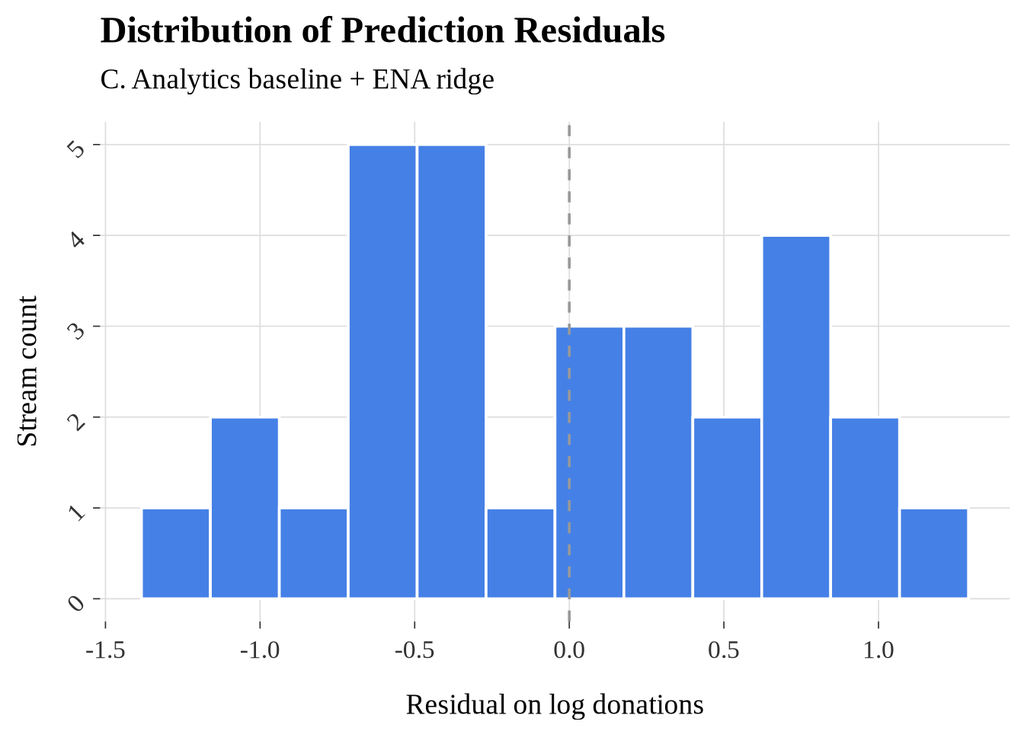

### Retained Predictor Interpretation

For penalized models, retained predictors are non-zero coefficients from the selected predictive model. They are not conventional statistical-significance tests. For linear models, the coefficient table includes standard errors, p-values, and confidence intervals, but these are still exploratory because the model was selected after comparison.

|  | Predictor | Coefficient | Abs Coefficient | Predictor Group | Coefficient Direction |
| --- | --- | --- | --- | --- | --- |
| 1 | lw_code_C1_code_CP06 | -1.420791024539812 | 1.420791024539812 | ENA lineweight | negative |
| 2 | lw_code_C1_code_CP11 | 0.9275744733707054 | 0.9275744733707054 | ENA lineweight | positive |
| 3 | lw_code_CP13_code_CP11 | 0.8850579797179537 | 0.8850579797179537 | ENA lineweight | positive |
| 4 | lw_code_A1b_code_E1a | 0.8802504856900407 | 0.8802504856900407 | ENA lineweight | positive |
| 5 | lw_code_CP11_code_A1b | 0.6510593146720773 | 0.6510593146720773 | ENA lineweight | positive |
| 6 | lw_code_CP11_code_CP06 | 0.6034492002115746 | 0.6034492002115746 | ENA lineweight | positive |
| 7 | lw_code_C1_code_A1b | -0.4263953888040877 | 0.4263953888040877 | ENA lineweight | negative |
| 8 | lw_code_CP11_code_E1a | 0.3273218336379212 | 0.3273218336379212 | ENA lineweight | positive |
| 9 | lw_code_B1_code_E1a | -0.3257646414178746 | 0.3257646414178746 | ENA lineweight | negative |
| 10 | lw_code_CP13_code_CP06 | 0.3235177264508859 | 0.3235177264508859 | ENA lineweight | positive |

[output cut: 30 more lines]

[interactive chart not shown]

### Stability Checks

This bootstrap-style resampling check asks whether the selected predictors are stable or whether they change substantially depending on which streams are included. With a small sample, instability is expected; stable predictors should appear repeatedly across resamples with reasonably consistent coefficient direction.

|  | Predictor | Predictor Group | Selection Frequency | Mean Coefficient | Median Coefficient | Coefficient Sign Consistency | Bootstrap Lower Bound | Bootstrap Upper Bound |
| --- | --- | --- | --- | --- | --- | --- | --- | --- |
| 1 | lw_code_C1_code_CP06 | ENA lineweight | 1 | -1.171700458140507 | -1.19521207551232 | 0.976 | -2.293853116972158 | -7.202292902995108e-05 |
| 2 | lw_code_C1_code_CP11 | ENA lineweight | 1 | 0.8692640031120521 | 0.8456688788055258 | 0.968 | -0.03068139404038375 | 2.099749329923174 |
| 3 | lw_code_A1b_code_E1a | ENA lineweight | 1 | 0.7435251368754857 | 0.7480962234088682 | 0.852 | -0.9636327577063791 | 2.250531651236353 |
| 4 | lw_code_CP13_code_CP11 | ENA lineweight | 1 | 0.741849993748384 | 0.7730924811154187 | 1 | 0.2543232479439891 | 1.020884340784335 |
| 5 | lw_code_CP11_code_CP06 | ENA lineweight | 1 | 0.6319222147686695 | 0.4827487397238182 | 0.956 | -0.1062153393352617 | 1.934368771328681 |
| 6 | lw_code_CP11_code_A1b | ENA lineweight | 1 | 0.5411691368266102 | 0.5749156292341797 | 0.908 | -0.4479211915580458 | 1.333490588039768 |
| 7 | lw_code_C1_code_E1a | ENA lineweight | 1 | 0.4423449648937935 | 0.1057090157551884 | 0.72 | -0.1749244803925608 | 2.006093876268713 |
| 8 | lw_code_C1_code_A1b | ENA lineweight | 1 | -0.3805013601380848 | -0.3964244458803855 | 0.86 | -1.25502206445021 | 0.4651531433984875 |
| 9 | lw_code_CP11_code_E1a | ENA lineweight | 1 | 0.3354864286519809 | 0.3043337335311687 | 0.624 | -1.16300505323792 | 2.041384774670372 |
| 10 | lw_code_B1_code_E1a | ENA lineweight | 1 | -0.3092748879941045 | -0.293610666002852 | 1 | -0.7843709717558431 | -0.06378035734441244 |

[output cut: 33 more lines]

[interactive chart not shown]

### Exploratory Inferential Follow-Up

This follow-up is separate from the predictive model. It uses the best model and the stability check to choose a small number of candidate predictors, then fits a compact ordinary linear model. Because the same data selected the predictors and estimated the follow-up model, p-values should be treated as descriptive and exploratory, not confirmatory.

|  | Predictor | Predictor Group | Estimate | Std Error | Statistic | P Value | Conf Low | Conf High | Term |
| --- | --- | --- | --- | --- | --- | --- | --- | --- | --- |
| 1 | (Intercept) | intercept | 3.579860002749909 | 3.183440219810338 | 1.124525593561543 | 0.2723895962069765 | -3.005587835274833 | 10.16530784077465 | (Intercept) |
| 2 | log_lines_of_text | baseline/control | 0.06781731016319915 | 0.3929217003348721 | 0.1725975177889159 | 0.8644776231673833 | -0.7450031555333266 | 0.8806377758597249 | log_lines_of_text |
| 3 | lw_code_C1_code_CP06 | ENA lineweight | -14.70871209611819 | 6.124236659680638 | -2.401721702388491 | 0.02479215193148408 | -27.37766087017387 | -2.039763322062507 | lw_code_C1_code_CP06 |
| 4 | lw_code_C1_code_CP11 | ENA lineweight | -2.231587390473197 | 6.159192455601325 | -0.3623181783260783 | 0.7204222341285973 | -14.97284773778846 | 10.50967295684207 | lw_code_C1_code_CP11 |
| 5 | lw_code_A1b_code_E1a | ENA lineweight | -2.400972927613007 | 7.103337770948922 | -0.3380063014083963 | 0.7384242376699599 | -17.09534666686357 | 12.29340081163756 | lw_code_A1b_code_E1a |
| 6 | lw_code_CP13_code_CP11 | ENA lineweight | 9.245837786314693 | 3.009720751010914 | 3.071991905963094 | 0.005393496345159156 | 3.019756049499833 | 15.47191952312955 | lw_code_CP13_code_CP11 |
| 7 | lw_code_CP11_code_CP06 | ENA lineweight | 1.005588553504076 | 4.237580460529598 | 0.2373025274376504 | 0.814523120618293 | -7.760514515933531 | 9.771691622941683 | lw_code_CP11_code_CP06 |

|  | R Squared | Adj R Squared | Sigma | Statistic | P Value | Df | Df Residual |
| --- | --- | --- | --- | --- | --- | --- | --- |
| 1 | 0.5033145539641874 | 0.3737444376070189 | 0.5386885607534245 | 3.884495654667532 | 0.007994754101321479 | 6 | 23 |

### Optional Non-Donation ENA Sensitivity Check

This sensitivity check is only relevant if the selected best model uses ENA predictors that include `gave_money`. Those predictors are donation-linked and can leak information about the outcome. The current main workflow removes those predictors from ENA modeling, but this check documents whether the sensitivity condition applies.

|  | Comparison | Model ID | Gave Money Ena Features Used | Model Family | N Streams | Rmse Log | Mae Log | R Squared Log | Rmse Dollars | Mae Dollars | Note |
| --- | --- | --- | --- | --- | --- | --- | --- | --- | --- | --- | --- |
| 1 | best_overall_model | C. Analytics baseline + ENA ridge | False | glmnet_alpha_0 | 30 | 0.6566272204609476 | 0.5733846002036136 | 0.03741938471855766 | 62.1562882423161 | 48.31218747269272 | Selected model does not use gave_money ENA predictors in the current workflow. |
| 2 | best_current_non_donation_ena_or_full_model | C. Analytics baseline + ENA ridge | False | glmnet_alpha_0 | 30 | 0.6566272204609476 | 0.5733846002036136 | 0.03741938471855766 | 62.1562882423161 | 48.31218747269272 | Selected model does not use gave_money ENA predictors in the current workflow. |
| 3 | analytics_baseline_without_ena | A. Analytics baseline | False | linear_lm | 30 | 0.7882274428770166 | 0.6454111708418035 | -0.3870829995829461 | 81.73015258126877 | 59.41406871711425 | Selected model does not use gave_money ENA predictors in the current workflow. |

### Written Interpretation Template

[output not shown]

## Findings Template

```
# Stream Donation Predictive Modeling Summary

This analysis is predictive and exploratory. It does not estimate causal effects.

- Number of streams modeled: 30
- Best cross-validated model on log donations: C. Analytics baseline + ENA ridge
- Best log-scale RMSE: 0.657
- Best dollar-scale MAE: $48.31

Questions to answer from the tables above:

1. Which model has the lowest leave-one-out RMSE and MAE?
2. Does the content-classification model improve on the baseline?
3. Do ENA lineweight models improve on metadata/content-only models?
4. Which retained ENA lineweights have the largest absolute coefficients?

Interpretation note: with a sample of roughly 30 streams, coefficient direction and variable selection should be treated as hypothesis-generating rather than definitive.
```